# Día 3

Curso teórico-práctico de introducción a la secuenciación con tecnología Oxford Nanopore Technologies para la caracterización de microorganismos

4 de Diciembre de 2024

### **1. Introducción**

#### Flujo de trabajo

En el práctico de hoy vamos a utilizar el ejemplo de uno de los genomas de *K. pneumoniae* obtenidos a partir de un brote nosocomial ocurrido en un hospital público de la ciudad de Montevideo en el año 2017. Esta muestra mostró un perfil de múltiple resistencia a varios antibióticos. A modo de determinar los genes y mecanismos moleculares involucrados en esta resistencia se realizó la secuenciación del genoma completo o WGS para esta y otras muestras causante del brote nosocomial. Se utilizó la plataforma Illumina HiSeq 4000 150 bp x2 para la generación de lecturas cortas y la plataforma MinION Mk1b para la generación de lecturas largas con la plataforma ONT.

**Parte 1: Control de calidad y filtrado de datos de secuenciación.**  
Para el control de calidad de los datos de Illumina estaremos utilizando las herramientas:  
[FastQC v0.12.1](https://github.com/s-andrews/FastQC)  
[Trimmomatic v0.39](https://github.com/usadellab/Trimmomatic)  
Para el control de calidad de los datos ONT utilizaremos:  
[NanoPlot v1.43.0](https://github.com/wdecoster/NanoPlot)  
[NanoFilt 2.8.0](https://github.com/wdecoster/nanofilt)

**Parte 2: Ensamblado del genoma y control de calidad.**  
Para el ensamblado con las lecturas de Illumina estaremos utilizando:  
[SPAdes genome assembler v4.0.0](https://github.com/ablab/spades)  
Para el ensamblado con lecturas ONT estaremos utilizando:  
[Flye v2.9.5-b1801](https://github.com/mikolmogorov/Flye)  
Para el ensamblado híbrido:  
[Unicycler v0.5.1](https://github.com/rrwick/Unicycler)  
El control de la calidad de los ensamblados, se realizará con:  
[QUAST v5.2.0](https://github.com/ablab/quast)

**Parte 3: Anotación de genes de RAM, virulencia y *cg*MLST. Clasificación de contigs plasmídicos.**  
Para la anotación de los genes de RAM, virulencia y *cg*MLST utilizaremos:  
[abricate v1.0.1](https://github.com/tseemann/abricate)  
[Kleborate v3.1.0](https://github.com/klebgenomics/Kleborate)  
Para la clasificación de contigs plasmídicos: [abricate v1.0.1](https://github.com/tseemann/abricate) [plasQuid](https://github.com/mgimenez720/plaSquid)

**Parte 4: Determinación de la relación filogenética de la muestra F19 con otras *K. pneumoniae* obtenidas de la base de datos.**  
Para determinar la relación filogenética de *K. pneumoniae* F19 con otras *K. pneumoniae* conocidas se utilizará:  
[parsnp v2.0.5](https://github.com/marbl/parsnp)

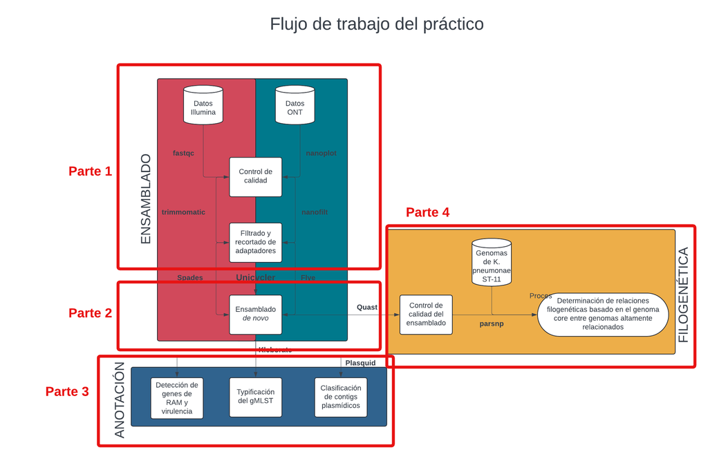

**Figura 1**: Flujo de trabajo de la sesión práctica.

### **2. Objetivos del día**

1. Acercamiento a **algunas** de las herramientas para el análisis primario de genomas bacterianos.
2. Realizar el control de calidad de datos de secuenciación (Illumina y ONT) obtenidos para una muestra de *K. pneumoniae* (F19).
3. Ensamblar el genoma de F19 con lecturas de secuenciaición Illumina, ONT e Illumina + ONT (ensamblado híbrido).
4. Realizar el control de calidad de los distintos ensamblados.
5. Anotar los genes de RAM y virulencia.
6. Clasificar los contigs plasmídicos.
7. Determinar la relación filogenética de la muestra F19, respecto a otros genomas de *K. pneumoniae* obtenidos de una base de datos pública.

# 3. Parte 1: control de calidad (QC)

### **3.1 Localización de los datos**

El *directorio de trabajo* se encuentra en:

```
cd $DIR_CURSO/curso_ont_2024
```

y activamos el ambiente de conda del curso

```
conda activate genomics
```

### **3.2. Control de calidad de los datos de secuenciación de Illumina**

Para realizar el control de calidad o QC ejecutamos el siguiente comando dentro del *directorio de trabajo*:

```
for i in illumina_data/*.fastq; do  echo $i; fastqc $i; done
```

o

```
source scripts/1.fastqc.sh
```

PREGUNTA: ¿Qué aspectos de la calidad se podrían mejorar?

Para filtrar secuencias de mala calidad utilizaremos Trimmomatic

```
mkdir -p illumina_data/trimmomatic_output

trimmomatic PE -phred33 \
illumina_data/F19_S225_R1.flt.fastq illumina_data/F19_S225_R2.flt.fastq \
illumina_data/trimmomatic_output/P1_F19_S225_R1.flt.fastq illumina_data/trimmomatic_output/U1_F19_S225_R1.flt.fastq \
illumina_data/trimmomatic_output/P2_F19_S225_R2.flt.fastq illumina_data/trimmomatic_output/U2_F19_S225_R2.flt.fastq \
LEADING:20 TRAILING:20 AVGQUAL:20 MINLEN:100 \
ILLUMINACLIP:database/illumina_adapters.fa:2:30:10
```

o

```
source scripts/2.trimommatic.sh
```

Análisis de los datos post-filtrado

```
for i in illumina_data/trimmomatic_output/*.fastq; do echo $i; fastqc $i; done
```

o

```
source scripts/3.fastqc.sh
```

### **3.4. Control de calidad de los datos de secuenciación ONT**

Para realizar el QC de los datos de secuenciación ONT ejecutamos en el *directorio de trabajo*

```
mkdir -p ont_data/nanoplot_fastq

for i in ont_data/*.fastq; do echo $i; NanoPlot --fastq $i --outdir ont_data/nanoplot_fastq/nanoplot_$i  --threads 4; done
mv ont_data/nanoplot_fastq/nanoplot_ont_data/F19_BC05_ONT.fastq/ ont_data/nanoplot_fastq/nanoplot_ont_data/F19_BC05_ONT/
```

```
google-chrome ont_data/nanoplot_fastq/nanoplot_ont_data/F19_BC05_ONT/NanoPlot-report.html
```

o

```
source scripts/3.nanoplot.sh
```

```
google-chrome ont_data/nanoplot_fastq/F19_BC05_ONT_nanoplot/NanoPlot-report.html
```

PREGUNTA: ¿Qué aspectos de la calidad se podrían mejorar de los datos ONT?

Filtrar los datos de ONT con **Nanofilt** ejecutando:

```
mkdir -p ont_data/nanofilt_output
for i in  ont_data/*.fastq; do echo $i; base_name=$(basename "$i" .fastq); NanoFilt -q 8 -l 200 --headcrop 70 --tailcrop 70 < "$i" > ont_data/nanofilt_output/filt_${base_name}.fastq; done
```

o

```
source scripts/4.nanofilt.sh
```

Analizar el control de calidad luego del filtrado

```
mkdir -p ont_data/nanofilt_output/nanoplot_fastq

for i in ont_data/nanofilt_output/*.fastq; do echo $i; NanoPlot --fastq $i --outdir ont_data/nanofilt_output/nanoplot_fastq/nanoplot_$i  --threads 4; done
mv ont_data/nanofilt_output/nanoplot_fastq/nanoplot_ont_data/F19_BC05_ONT.fastq/ ont_data/nanoplot_fastq/nanofilt_output/nanoplot_ont_data/F19_BC05_ONT
```

```
google-chrome ont_data/nanofilt_output/nanoplot_fastq/nanoplot_ont_data/nanofilt_output/filt_F19_BC05_ONT.fastq/NanoPlot-report.html
```

o

```
source scripts/4.nanoplot2.sh
```

OPCIONAL: Clasificación taxonómica de las lecturas de secuenciación pre-procesadas con [*Kraken2*](https://github.com/DerrickWood/kraken2). A modo de determinar potenciales contaminaciones durante el procedimiento de extracción de ADN de las muestras, podemos utilizar un clasificador de lecturas de secuenciación, previo al ensamlado. Esto nos puede alertar de potenciales contaminaciones en la muestra. A partir de esto podemos optar por la decontaminación de las lecturas de secuenciación o decidir repetir el experimento desde la etapa de extracción de ADN del aislamiento.

Para los datos de secuenciación Illumina ejecutar los siguientes comandos en el *directorio de trabajo*

```
mkdir -p kraken2_output/Illumina

kraken2 --db database/kraken2DB --report kraken2_output/Illumina/report_F19_R1.txt --output kraken2_output/Illumina/output_F19_R1.txt illumina_data/trimmomatic_output/P1_F19_S225_R1.flt.fastq
```

```
kraken2 --db database/kraken2DB --report kraken2_output/Illumina/report_F19_R2.txt --output kraken2_output/Illumina/output_F19_R2.txt illumina_data/trimmomatic_output/P2_F19_S225_R2.flt.fastq
```

Para los datos de secuenciación ONT

```
mkdir -p kraken2_output/ONT

kraken2 --db database/kraken2DB --report kraken2_output/ONT/report_F19_ONT.txt --output kraken2_output/ONT/output_F19_R2.txt ont_data/nanofilt_output/filt_F19_BC05_ONT.fastq
```

# 4. Parte 2: Ensamblado genómico

### **4.1. Ensamblado genómico a partir de lecturas de secuenciación cortas con *SPAdes***

```
mkdir -p ensamblado/SPAdes/F19_S225

spades.py -1 illumina_data/trimmomatic_output/P1_F19_S225_R1.flt.fastq -2 illumina_data/trimmomatic_output/P2_F19_S225_R2.flt.fastq -t 4 -o ensamblado/SPAdes/F19_S225
```

o

```
source scripts/5.spades.sh
```

### **4.2. Ensamblado genómico a partir de lecturas de secuenciación larga con *Flye***

```
mkdir -p ensamblado/Flye

flye --nano-raw ont_data/nanofilt_output/filt_F19_BC05_ONT.fastq --out-dir ensamblado/Flye/ --genome-size 5g --threads 8 --iterations 2
```

o

```
source scripts/6.flye.sh
```

### **4.3. Ensamblado genómico híbrido a partir de lecturas de secuenciación cortas y largas con *Unicycler***

```
mkdir -p ensamblado/Unicycler

unicycler -1 illumina_data/trimmomatic_output/P1_F19_S225_R1.flt.fastq -2 illumina_data/trimmomatic_output/P2_F19_S225_R2.flt.fastq -l ont_data/nanofilt_output/filt_F19_BC05_ONT.fastq -t 8 -o ensamblado/Unicycler/
```

o

```
source scripts/7.unicycler.sh
```

PREGUNTA: ¿Cuál es el mejor ensamblado en términos de cantidad de contigs, largo total del ensamblado, completitud y precisión de secuencia?

Para responder en parte esta pregunta utilice el software *Quast* para las tres estrategias.

Primero vamos a crear un nuevo directorio conteniendo solamente los ensamblados de las tres estrategias y vamos a renombrarlos según las mismas.

```
mkdir -p genomas

cp ensamblado/SPAdes/F19_S225/contigs.fasta genomas/spades.fasta
cp ensamblado/Flye/filt_F19_BC05_ONT/assembly.fasta genomas/flye.fasta
cp ensamblado/Unicycler/F19_S225/assembly.fasta genomas/unicycler.fasta
```

```
mkdir -p genomas/quast

for i in genomas/*.fasta; do echo $i; base_name=$(basename "$i" .fasta); quast $i -o genomas/quast/quast_${base_name}; done
```

Resumir la infromación del *output* de **Quast**

```
grep "contigs (>= 0 bp)" genomas/quast/quast_*/report.tsv
grep "Total length (>= 0 bp)" genomas/quast/quast_*/report.tsv
```

Visualizar con **Bandage** los ensamblados cargado los archivos *.gfa* de cada tipo de ensamblado

```
Bandage
```

A partir de los archivos de grafos .gfa podemos observar a los genomas ensamblados de la siguiente forma:

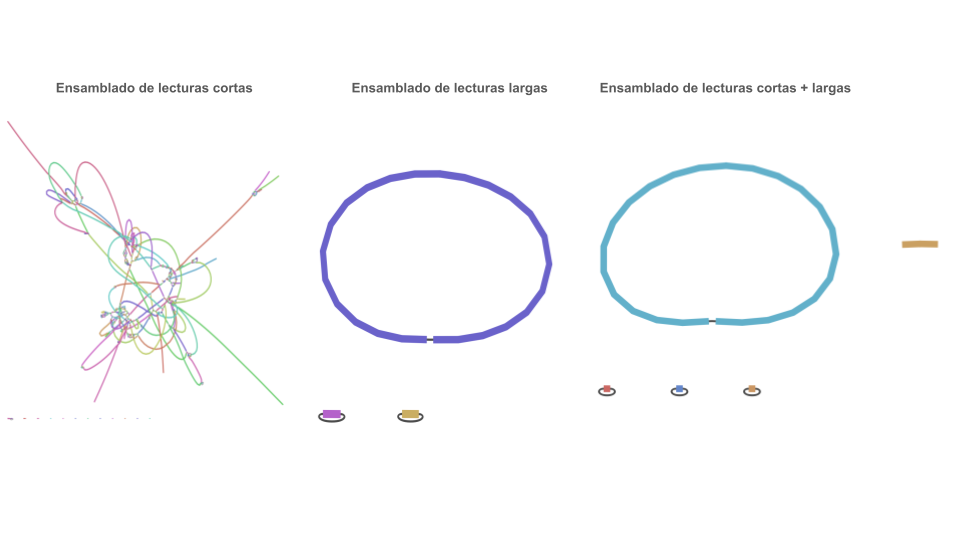

Recuerde que en cada una de las ejecuciones del ensamblados se generan reportes, explore los subdirectorios de ensamblado para obtener más información.

# 5. Parte 3: Anotación de genes de RAM y virulencia. Detección del *cg*MLST y clasificación de contigs plasmídicos.

### **5.1. Detección de genes de RAM y virulencia**

Una vez que tenemos los ensamblados genómicos **Kleborate** utilizaremos para identificar el número de genes RAM, virulencia y *cg*MLST

```
kleborate -a genomas/*.fasta -o genomas/kleborate -p kpsc
```

```
head -n 50 genomas/kleborate/klebsiella_pneumo_complex_output.txt
```

Utilizaremos el siguiente script de R para extraer parte de la información del *output* de **Kleborate**

```
Rscript scripts/8.rscript.R
```

**Abrir la tabla correspondiente**

PREGUNTA: ¿Cuáles son las principales diferencias que se observan entre los distintos ensamblados en términos de anotación de genes de RAM y virulencia? ¿Por qué cree que pueden darse diferencias en la determinación del *g*MLST en los distintos ensamblados?

Existen otras herramientas de anotación de genes de RAM y virulencia

```
mkdir -p genomas/abricate
abricate --db card genomas/*.fasta >> genomas/abricate/ram.tsv
abricate --db vfdb genomas/*.fasta >> genomas/abricate/vfdb.tsv
```

Si representamos obtenidos con este comando en el formato heatmap deberíamos obtener los siguientes resultados:

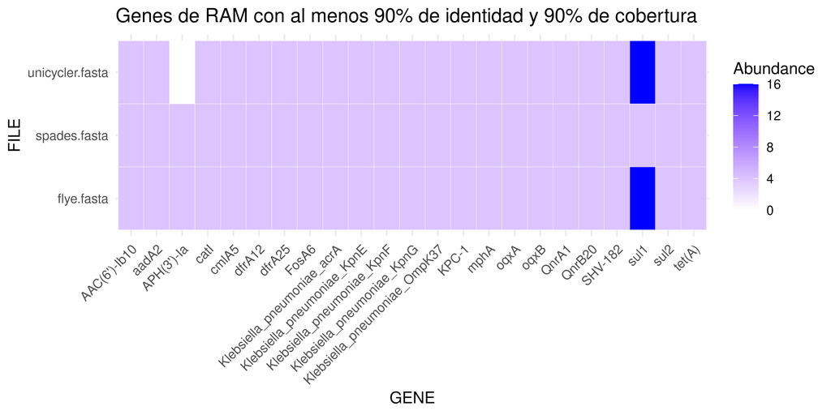

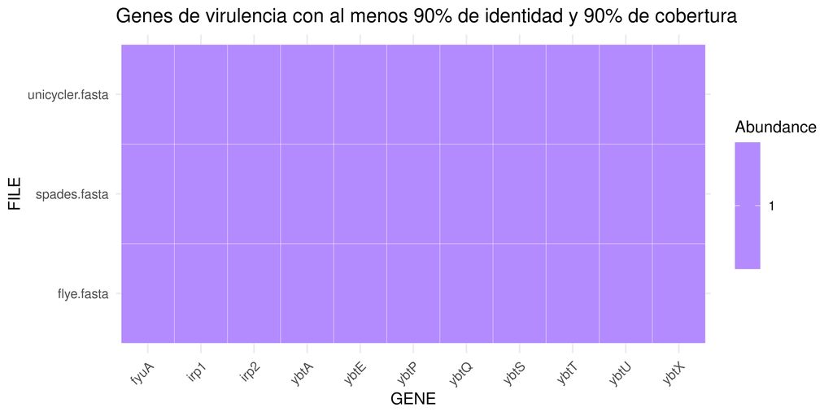

PREGUNTA: ¿Qué otras estrategias bioinformáticas conoce para la confirmación de la anotación? ¿Qué estrategias en el laboratorio podría utilizar para la confirmación de la expresión fenotípica de la potencial resistencia detectada?

### **5.2. Clasificación de contigs plasmídicos**

Una de las aternativas para la clasificación rápida es la utilización de *Abricate* con la base de datos de *plasmidfinder* para la obtención de la información. Esta estrategia se basa en la búsqueda de replicones de los plásmidos.

```
abricate --db plasmidfinder genomas/*.fasta >> genomas/abricate/plasmidfinder.tsv
```

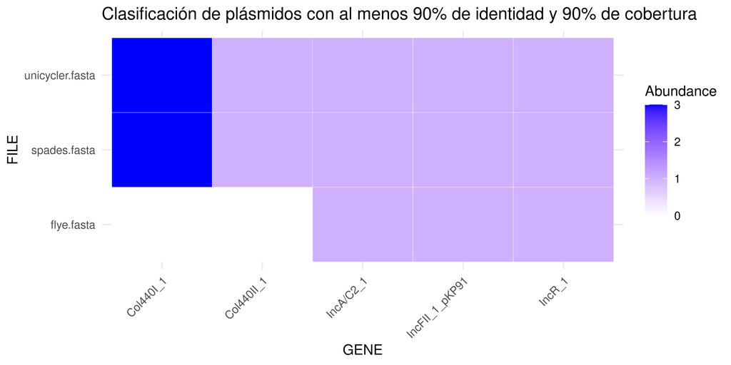

Otras de las alternativas es la utilización de *plaSquid*, una herramienta que utiliza la clasificación tanto de replicones y grupos de movilidad a partir de contigs obtenidos luego del ensamblado.

```
nextflow run mgimenez720/plaSquid --contigs genomas/*.fasta
```

PREGUNTA: ¿El gen KPC se encuentra en un plásmido? ¿En cuál?

```
mkdir -p genomas/contigs_unicycler
seqkit split -i -O genomas/contigs_unicycler/ genomas/unicycler.fasta
for i in genomas/contigs_unicycler/unicycler.part_*; do echo $i; abricate --db resfinder $i >> genomas/contigs_unicycler/unicycler_resfinder.tsv; done
for i in genomas/contigs_unicycler/unicycler.part_*; do echo $i; abricate --db plasmidfinder $i >> genomas/contigs_unicycler/unicycler_plasmidfinder.tsv; done
grep "KPC" genomas/contigs_unicycler/unicycler_resfinder.tsv
```

# 6. Parte 4: Determinación filogenética con otros genomas altamente relacionados.

### **6.1. Dataset de genomas altamente relacionados de *K. pneumoniae* ST-11**

La búsqueda en la base de datos [BV-BRC: Bacterial and Viral Bioinformatics Resource Center](https://www.bv-brc.org/) de los genomas correspondientes a *K. pneumoniae* completos y de buena calidad muestra que existen un total de 2467. De los cuales 493 pertenecen al mismo *cg*MLST que los aislamientos locales obtenidos del brote nosocomial. De ese total 460 se encuentran depositados en la base de datos NCBI. Utilizando la herramienta [ncbi-datasets-cli](https://www.ncbi.nlm.nih.gov/datasets/docs/v2/download-and-install/) se descargaron los genomas disponibles (459). Se determinó el perfil de RAM y virulenacia, asi como la detección de plásmidos.

Para generar una filogenia basada en SNPs del genoma *core*, utilizaremos la herramienta **parsnp**, con un subset de secuencias (200) junto con genomas del ST-258, del cual deriva el ST-11 (10).

Abra la filogenia obtenida con *parsnp* utilizando *figree*

```
figtree kp_dataset/genomes/parsnp_kp_ch/parsnp.tree
```

Identifique las secuencias de Uruguay en el árbol. Interprete el significado de la filogenia basada en los SNPs del genoma *core*.

¿Observa un patrón similar al de la figura a continuación? La misma fue creada con la totalidad de secuencias de alta calidad del ST-11 y ST-258 de la base de datos, junto con los genomas de *K. pneumoniae* de Uruguay.

[figure not shown]

¿A nivel de país?

[figure not shown]

PREGUNTA: ¿En base a las características analizadas de las secuencias de Uruguay, qué podría afirmar respecto al genoma ensamblado F19 y las demás secuencias de Uruguay y Sudamérica?